# Mid-project report

Siim and Maria

9/3/2021

First some remarks above the report below and an issue that came up:

I have used the data about Paying Customers (PC-s from now on) here because there is some confusion about how you count Paying Customers and don’t regard the NPC-s who only subscribe a short period Paying Customers anymore at the end of the test. So these peoples MRR is essentially zero so the analysis below uses only Paying Customers and conversion to Paying Customers. In my view (if i understand correctly) this is somewhat problematic because then the status as Paying Customer depends on how long you run the test (which seems kind of arbitrary as far as PC vs NPC status goes). NPC-s who only subscribe a short period also bring in revenue altho not reocurring revenue…so they shoud still be counted toward revenue…or not? Since we are modeling the future here, and in the future there will also be people coming to the website who subscribe for a short period but still bring in revenue, so they so count towards the MRR maybe? Or is there some other reason why you strictly only deal with people who happen to PC-s at the end of a test? Anyway the following is based on MRR which comes from people who are PC-s at the end of the test. We can discuss wednesday:).. If somewhere below i have written NPC then it should be PC.

NB! **Some number can be slightly different on the tables and graphs compared to the text explanations because the simulation runs again everytime i produce the document and the text stays the same if i don’t change it (too much work) and i forgot to set a seed in the beginning (make it so the outpute doesn’t change) and would have to go over the whole text to change the numbers.**

### Moving on to the report

This thing here and hopefully the tool in the end has three major parts:  
1) Conversion rate analysis  
2) Mean MRR per PC analysis  
3) Expected MRR per visitor (or signup) analysis.

And this is the order thing will be handled in the report below.

### Conversion rate analysis

Here you basically see the table you would get with the original A/B testing tool with the same data. I have entered the proportions in here (sample size and PCs). PC proportions are important for MRR calculation and it will be clear later why. You could actually use singups as the sample size and take the rate of PC-s from that, which could also give important insight. That would enable a different interpretation of the overall MRR explained later.

Conversion rate statistics

| variation | n | conversions | Prob. of outperforming | CR | uplift |
| --- | --- | --- | --- | --- | --- |
| A | 31665 | 472 | 65.88% | 1.49% |  |
| B | 31752 | 460 | 34.12% | 1.45% | -2.71% |

This is a graph of the model implied probability distribution of possible conversion rates for the two variations. The thicker interval beneath the curve is the 66% interval and the thinner one is the 95% one. They show the probability of the true conversion rate being in a certain interval. In the actual tool i can add numbers to the endpoints of these intervals or possibly a slider on the graph to see the value at each point on the curve.

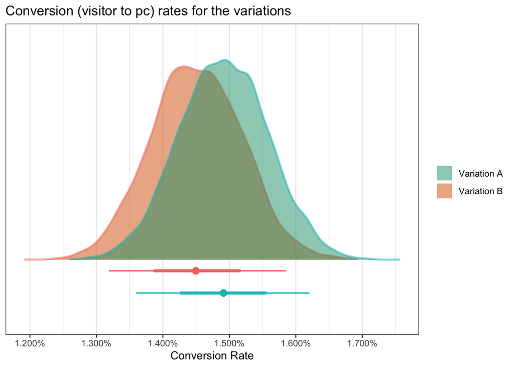

This is the probability distribution of the difference of conversion rates. This is also displayed on the original tool you are using now. With these rates (visitors vs pc-s) the original tool doesn’t give a very clear output on this tho.

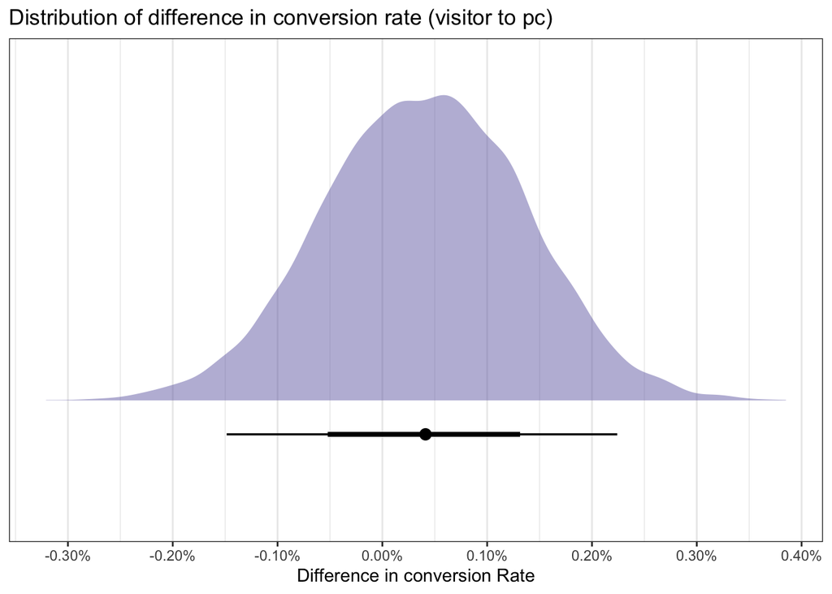

## MRR per NPC analysis

From here on out everything pertains to a datafile from zeppelin you would have to enter into the machine. This first part here shows descriptive statistics about the MRR of the **raw data**. No models have been applied yet. I can add anything you want here, but for now i took the liberty to put these things in the table:

1. mean
2. standard deviation
3. max MRR contribution within a variation
4. min MRR contribution within a variation
5. 25% quantile: the value from which 25% of values (by count) are lower (and 75% higher)
6. median: the value under which and over which 50% of values lie
7. 75% quantile: the value from which 75% of value are lower (and 25% higher)

The graph displays the distribution of the actual data points (in purple) or in other words each company that became an NPC during the test with the MRR on the y axis.

The manta-ray looking things are violin-plots which are basically the regular probability distribution plot (like the ones above) but turned on its side and mirrored on both sides. So a more pronounced the peak means more values (PC-s) in that area of MRR.

The box-plots in the middle show the median (the middle line of the box) and the edges of the boxes show the 25th and 75th quantiles so 50% of the data lie within the box and with the highest concentration.

Overview of raw PC data

[output not shown]

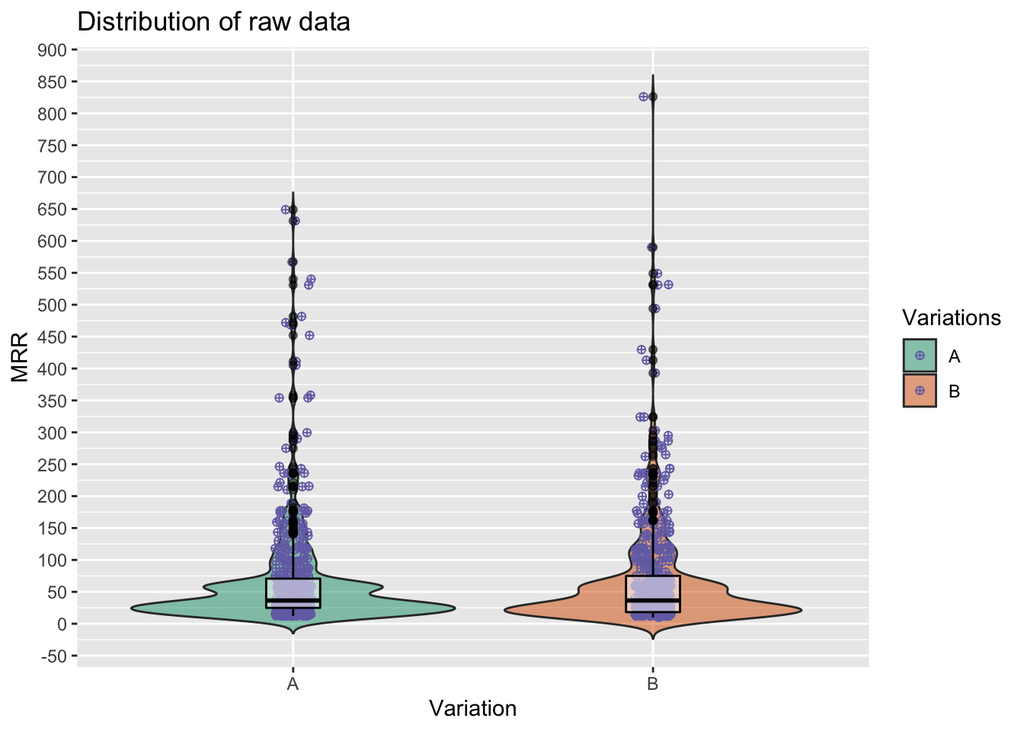

Next we move into model territory. The table here shows the output of the model which simulates mean MRR per company.  
1) **Estimate** column tell you what the models predicts the most likley mean MRR per one PC is for the variations.  
2) **Est.Error** column tells you what the standard-deviation of that prediction of mean MRR per PC is in that prediction.  
3) **Q2.5 and Q97.5** are basically the thin lines on the graph below or in other words the borders of MRR values within which the true MRR per NPC lies in with 95% probability according to the model.  
4) **Prob. of outperforming** tells you the probability that the MRR per PC is bigger for one or the other variation

Table of model implied estimates of mean MRR per PC per variation

| Variation | Estimate | Est.Error | Q2.5 | Q97.5 | Prob. of outperforming |
| --- | --- | --- | --- | --- | --- |
| A | 35.25991 | 1.604348 | 32.28336 | 38.48471 | 88.6% |
| B | 32.75220 | 1.787652 | 29.41263 | 36.42231 | 11.4% |

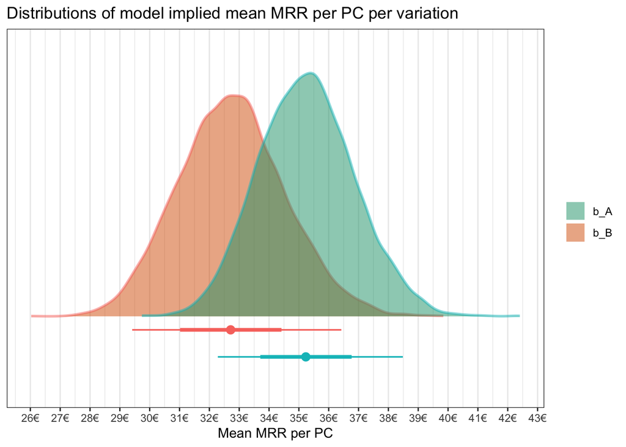

Here is another plot describing the same model. This is the probability distribution for the difference of **the mean MRR per NPC**. This shows the probability distribution of the expected difference of mean MRR per PC between variations. Here the area over 0 EUR coincides with the above tables “Prob. of being better” for variation A and the area under 0 EUR is basically the “Prob. of being better” for variation B.

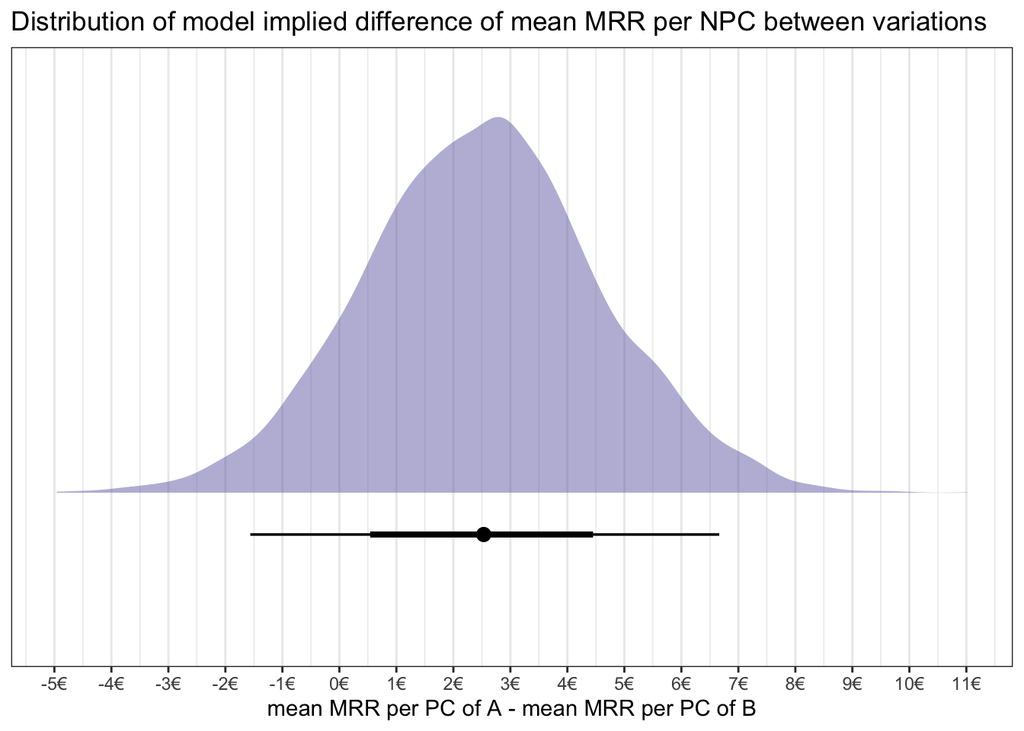

## MRR per visitor (or signup) analysis

Now we move on to the third part where both of the previous parts are combined. Conceptually this means that we take the probability of a single **visitor** being converted (conversion rate from visitor to PC) and multiply that probability by the value they are expected to produce in MRR. With that we get the expected value of a single **visitor**. The great thing here is that, if in the first part of conversion rate analysis you don’t enter the **visitor** and “PC” numbers but you enter the **“signup”** and “PC” numbers, then you will get here the expected MRR per **signup** not per **visitor**. So it is possible to see how much MRR a variation is expected to produce per visitor OR per singup. Thats why it is good to be able to enter the proportions in the beginning.

We start with a table again. Here the mean gives you the expected MRR per each visitor. SD gives you the standard deviation of that mean MRR per visitor. Quantiles give you again the points of MRR between which 50% of the values lie. Prob. of outperforming stems again from the last plot (of differences) below. The Prob. of outperforming tells you the probability of per visitor MRR being bigger in one or the other site.

We can see here that the Prob. of outperforming is actually smaller on MRR per visitor than on MRR per PC (that we saw before). This comes from the fact that the conversion rate (the first part of analysis) is more even between the variations than MRR per PC (where variation A outshines quite a bit). The more even conversion rate corrects the overall expected MRR per visitor a little bit and draws it back.

Difference of MRR per visitor/signup

| Variation | mean | SD | Q25 | Q75 | Prob. of outperforming | MRR per 1000 visitors |
| --- | --- | --- | --- | --- | --- | --- |
| A | 0.53 | 0 | 0.46 | 0.59 | 87% | 530 |
| B | 0.48 | 0 | 0.41 | 0.55 | 13% | 480 |

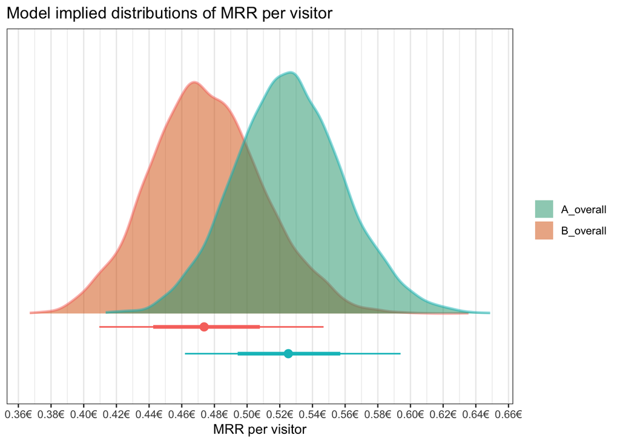

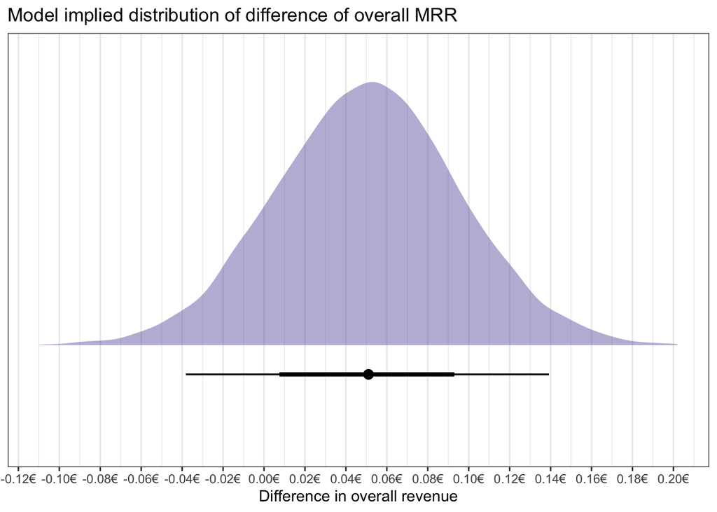